# Visualization Assignment 3

But this doesn't adjust for the population levels, which might be significantly different in the different areas.

We don't have direct population counts in this data set, but we do have % of crowded housing which could be used as an imperfect proxy.

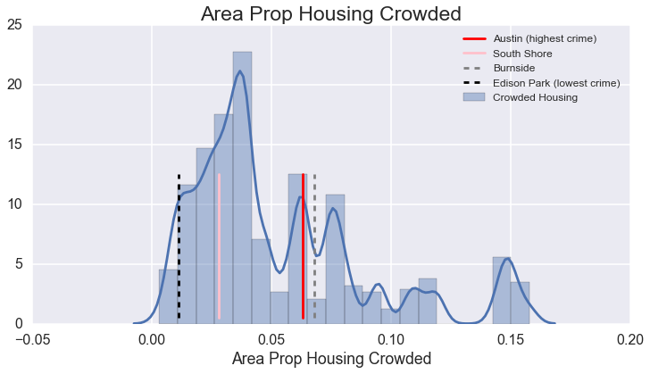

```python
sns.distplot(crimeb['Area Prop Housing Crowded'], bins=20, label='Crowded Housing')
plt.axvline(x=austin['Area Prop Housing Crowded'][0], ymin=0.02, ymax=0.5, hold=None, color = 'r', label = 'Austin (highest crime)')
plt.axvline(x=south['Area Prop Housing Crowded'][0], ymin=0.02, ymax=0.5, hold=None, color = 'pink', label = 'South Shore')
plt.axvline(x=burnside['Area Prop Housing Crowded'][0], ymin=0.02, ymax=0.5, hold=None, color = 'grey', linestyle= '--', label = 'Burnside')
plt.axvline(x=edison['Area Prop Housing Crowded'][0], ymin=0.02, ymax=0.5, hold=None, color = 'black', linestyle= '--', label = 'Edison Park (lowest crime)')

plt.title("Area Prop Housing Crowded", fontsize= 23)
plt.legend(fontsize = 12);
```

Again, this shows mixed results. Edison Park is at the bottom of the crowded housing scale, so we'd probably expect there to be a lower population in this area and thus, lower crime counts. (Unless it's a vastly larger area than the others in this group.) But, Burnside has the second lowest crime counts and has more crowded housing that Austin, with the highest crime counts.

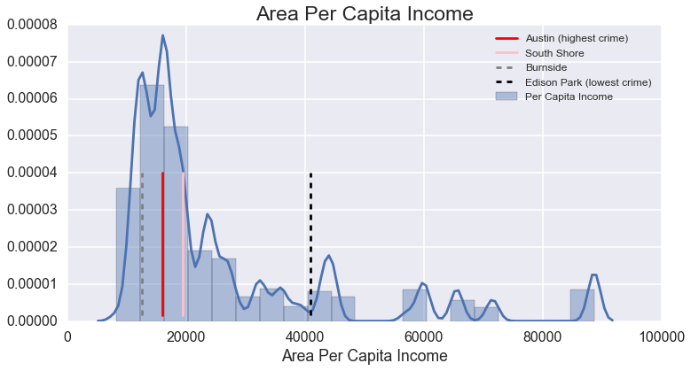

```python
sns.distplot(crimeb['Area Per Capita Income'], bins=20, label='Per Capita Income')
plt.axvline(x=austin['Area Per Capita Income'][0], ymin=0.02, ymax=0.5, hold=None, color = 'r', label = 'Austin (highest crime)')
plt.axvline(x=south['Area Per Capita Income'][0], ymin=0.02, ymax=0.5, hold=None, color = 'pink', label = 'South Shore')
plt.axvline(x=burnside['Area Per Capita Income'][0], ymin=0.02, ymax=0.5, hold=None, color = 'grey', linestyle= '--', label = 'Burnside')
plt.axvline(x=edison['Area Per Capita Income'][0], ymin=0.02, ymax=0.5, hold=None, color = 'black', linestyle= '--', label = 'Edison Park (lowest crime)')

plt.title("Area Per Capita Income", fontsize= 23)
plt.legend(fontsize = 12);
```

These results, while not definitive, provide a clearer picture and evidence that per capita income is a cofactor in crime.

The lowest crime area definitely has one of the higher per capita income levels, while the two highest crime areas are on the lower end of the scale.

Burnside seems to be an outlier in all of the plots so far.

In light of that, we replaced Burnside with Forest Glen in the Per Capita Income plot to see if the results are closer to what we'd expect.

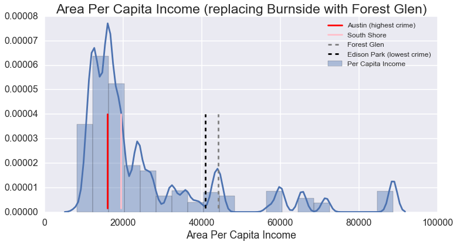

```python
sns.distplot(crimeb['Area Per Capita Income'], bins=20, label='Per Capita Income')
plt.axvline(x=austin['Area Per Capita Income'][0], ymin=0.02, ymax=0.5, hold=None, color = 'r', label = 'Austin (highest crime)')
plt.axvline(x=south['Area Per Capita Income'][0], ymin=0.02, ymax=0.5, hold=None, color = 'pink', label = 'South Shore')
plt.axvline(x=forest['Area Per Capita Income'][0], ymin=0.02, ymax=0.5, hold=None, color = 'grey', linestyle= '--', label = 'Forest Glen')
plt.axvline(x=edison['Area Per Capita Income'][0], ymin=0.02, ymax=0.5, hold=None, color = 'black', linestyle= '--', label = 'Edison Park (lowest crime)')

plt.title("Area Per Capita Income (replacing Burnside with Forest Glen)", fontsize= 23)
plt.legend(fontsize = 12);
```

This looks a lot closer to what we'd expect and shows a clear trend.

For the remaining plots, Forest Glen will be used instead of Burnside.

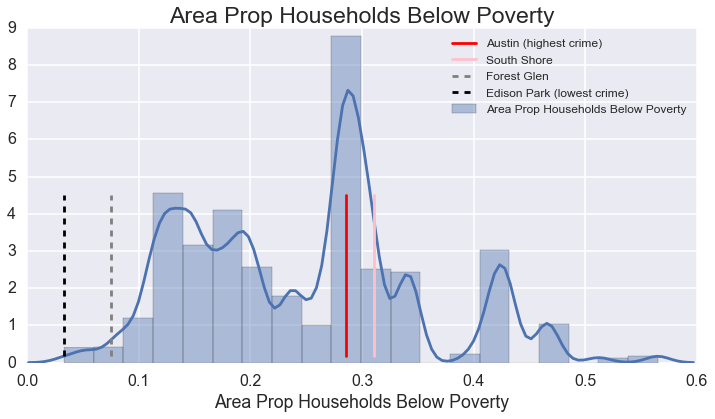

```python
sns.distplot(crimeb['Area Prop Households Below Poverty'], bins=20, label='Area Prop Households Below Poverty')
plt.axvline(x=austin['Area Prop Households Below Poverty'][0], ymin=0.02, ymax=0.5, hold=None, color = 'r', label = 'Austin (highest crime)')
plt.axvline(x=south['Area Prop Households Below Poverty'][0], ymin=0.02, ymax=0.5, hold=None, color = 'pink', label = 'South Shore')
plt.axvline(x=forest['Area Prop Households Below Poverty'][0], ymin=0.02, ymax=0.5, hold=None, color = 'grey', linestyle= '--', label = 'Forest Glen')
plt.axvline(x=edison['Area Prop Households Below Poverty'][0], ymin=0.02, ymax=0.5, hold=None, color = 'black', linestyle= '--', label = 'Edison Park (lowest crime)')

plt.title("Area Prop Households Below Poverty", fontsize= 23)
plt.legend(fontsize = 12);
```

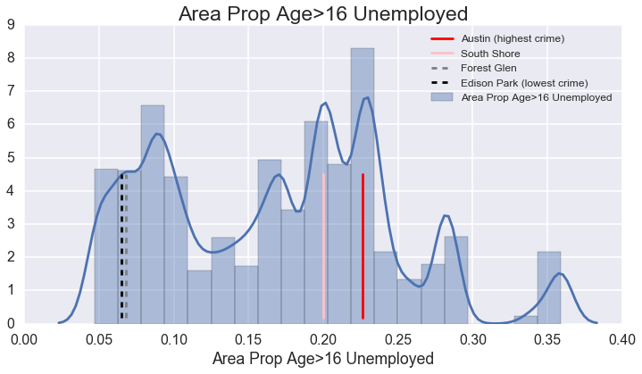

```python
sns.distplot(crimeb['Area Prop Age>16 Unemployed'], bins=20, label='Area Prop Age>16 Unemployed')
plt.axvline(x=austin['Area Prop Age>16 Unemployed'][0], ymin=0.02, ymax=0.5, hold=None, color = 'r', label = 'Austin (highest crime)')
plt.axvline(x=south['Area Prop Age>16 Unemployed'][0], ymin=0.02, ymax=0.5, hold=None, color = 'pink', label = 'South Shore')
plt.axvline(x=forest['Area Prop Age>16 Unemployed'][0], ymin=0.02, ymax=0.5, hold=None, color = 'grey', linestyle= '--', label = 'Forest Glen')
plt.axvline(x=edison['Area Prop Age>16 Unemployed'][0], ymin=0.02, ymax=0.5, hold=None, color = 'black', linestyle= '--', label = 'Edison Park (lowest crime)')

plt.title("Area Prop Age>16 Unemployed", fontsize= 23)
plt.legend(fontsize = 12);
```

Again a clear trend can be seen. The lower the unemployment rate, the lower the amount of crime in the area, at least when we look at the far ends of the crime count spectrum.

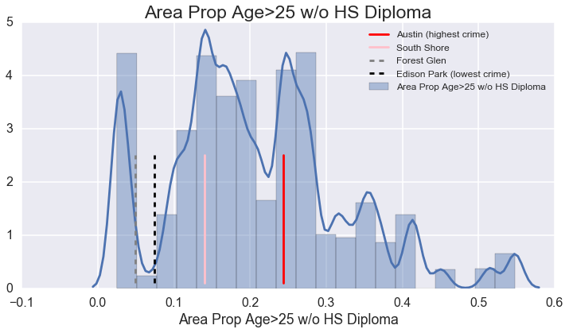

```python
sns.distplot(crimeb['Area Prop Age>25 w/o HS Diploma'], bins=20, label='Area Prop Age>25 w/o HS Diploma')
plt.axvline(x=austin['Area Prop Age>25 w/o HS Diploma'][0], ymin=0.02, ymax=0.5, hold=None, color = 'r', label = 'Austin (highest crime)')
plt.axvline(x=south['Area Prop Age>25 w/o HS Diploma'][0], ymin=0.02, ymax=0.5, hold=None, color = 'pink', label = 'South Shore')
plt.axvline(x=forest['Area Prop Age>25 w/o HS Diploma'][0], ymin=0.02, ymax=0.5, hold=None, color = 'grey', linestyle= '--', label = 'Forest Glen')
plt.axvline(x=edison['Area Prop Age>25 w/o HS Diploma'][0], ymin=0.02, ymax=0.5, hold=None, color = 'black', linestyle= '--', label = 'Edison Park (lowest crime)')

plt.title("Area Prop Age>25 w/o HS Diploma", fontsize= 23)
plt.legend(fontsize = 12);
```

The association between crime and adults without a high school diploma seems to be weaker than the other metrics.

## Some Demographic Data Exploration

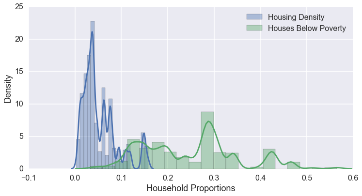

```python
sns.distplot(demos['Area Prop Housing Crowded'], bins=20, label='Housing Density')
sns.distplot(demos['Area Prop Households Below Poverty'], bins=20, label='Houses Below Poverty')
#sns.distplot(demos.Humidity, bins=20, label='Hum')

plt.xlabel('Household Proportions', size=18)
plt.ylabel('Density', size=18)
plt.legend(loc='upper right')
plt.show();
```

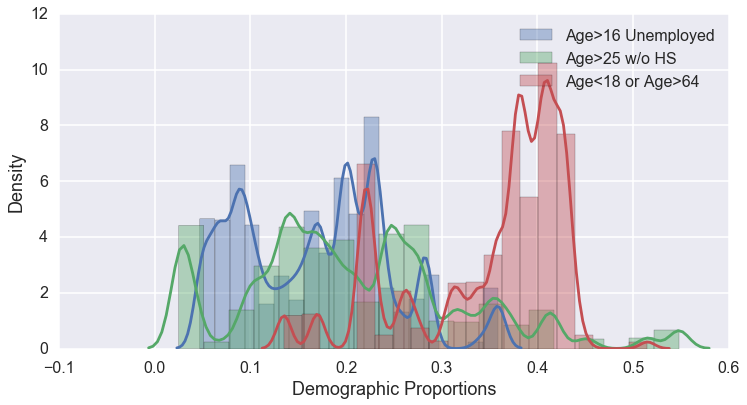

```python
sns.distplot(demos['Area Prop Age>16 Unemployed'], bins=20, label='Age>16 Unemployed')
sns.distplot(demos['Area Prop Age>25 w/o HS Diploma'], bins=20, label='Age>25 w/o HS')
sns.distplot(demos['Area Prop Age<18 or Age>64'], bins=20, label='Age<18 or Age>64')

plt.xlabel('Demographic Proportions', size=18)
plt.ylabel('Density', size=18)
plt.legend(loc='upper right')
plt.show();
```